# Projet Data Science - 08/01/2023

### Grégoire BRETON - Damien FOURNIER - Arthur GERVAIS

# Introduction

L'objectif de ce travail consiste à estimer des primes pures d'une assurance auto pour l'année à venir en se basant sur un historique de 60 000 polices observées pendant au moins 3 mois lors de l'année précédente. Le but est alors de créer un modèle de tarification qui devra être utilisé pour proposer des primes à 20 000 nouveaux assurés.

## Exploration des Données

Les données sont séparées en un trainig set et un test set pour évaluer notre modèle. Le training set contient 16 variables dont deux variables directement liées au montants des primes et qu'il nous faut prédire : `claimNumber` le nombre de sinistre causé par un assuré et `claimValue` le montant total des sinistres de l'assuré. Parmis les variables explicatives, on a 8 variables catégorielles (`gender`, `carType`, `carCategory`, `occupation`, `carGroup`, `material`, `subRegion` et `region`) et 5 variables continues (`age`, `bonus`, `carValue`, `cityDensity` et `exposure`).  
Seul `exposure` n'est pas présent dans le test set.

Une première étude a été réalisée sous R afin de mieux comprendre les données. Nous n'inclueront pas l'étude complète mais seulement quelques analyses et graphiques qui nous ont aidés à exploiter les variables.

Nous avons également réalisé une régression afin d'obtenir les variables significatives pour la prédiction de nombre de sinistres et pour la prédiction du montnat des sinistres:

[figure not shown]

##### Region et subRegion

Nous avons transformé la variable ordinale `claimNumber` en variable catégorielle `catClaimNumber` afin de regrouper les individus ayant plus de 3 sinistres. Les modalités sont `zero`, `un`, `deux` et `p3`.

Nous avons alors effectué des tests de contingence du $\chi^2$ sur chaque région afin d'observer des corrélations, ce qui est récapitulé dans le mosaic plot ci dessous :

[figure not shown]

En bleu, il y a plus d’individus observé qu’attendu sous l’hypothèse d’absence de liens entre variables, il y a donc surreprésentativité des effectifs observés par rapport aux théoriques. A l'inverse, en rouge, il y a moins d’individus qu’attendu sous l’hypothèse d’absence de liens entre les variables, donc une sous représentativité des effectifs observés par rapport aux théoriques.

Dans les table blanches, il y a peu de chance que les variables soient liées.

##### Bonus

Ici le bonus représente la quantité (positive ou négative) a ajouter à la prime.

[figure not shown]

Comme on peut observer à droite `claimValue` a également été catégorisée afin de réaliser des études de contingence du $\chi^2$. `u500` correspond à des montants inférieurs à 500 €. L'étude de contingence est réalisée sur les assurés ayant eu au moins un sinistre.  
On peut aussi remarquer que plus ont a un bonus élevé, plus le montant moyen du sinistre est faible, indiquant que les individus ayant un bonus élevé sont plus probablement des "risques attritionnels".

##### Age

Nous avons aussi essayer de faire du clustering sur l'age des assurés afin de transformer cette variable ordinale en variable catégorielle. Le clustering a été réalisé sous R entre les variables `age`, `claimNumber` et `claimValue`.

[figure not shown]

Nous avons finalement décidé de garder l'age tel quel.

##### Exposure

La variable *exposure* correspond aux nombre de jours d'obseration sur l'année précédente d'un individu.

[figure not shown]

La valeur d'exposure à gauche correspond à 37. Elle est plutôt aberrante en la considèrant en tant que singleton... On peut supposer qu'il s'agit d'un proxy pour toutes les expo entre 0 et 90. Nous n'exploitons pas cette variable par la suite.  
On aurait pu transformer le montnat de sinistres ou le nombre de sinistres en prenant en compte cette variable. Par exemple, les individus d'exposure = 365 ne verraient pas leur montnats de sinistres changer mais plus l'exposure est récente, plus le montnat transformé pourraitêtre élevé, afin de refléter une sorte de risque par jour.

## Data Management

Par la suite, nous utiliserons les notations suivantes :

- $\mathbf{x_i}$ représente le vecteur des variables explicatives pour l'individu $i$
- $Y_i$ représente le montant de sinistre de l'individu $i$
- $X_i$ représente le nombre de sinistre de l'individu $i$

```python
SEED = 42
```

```python
import pandas as pd
import numpy as np
import matplotlib.pyplot as plt
import seaborn as sns

from sklearn.ensemble import RandomForestClassifier, RandomForestRegressor
from sklearn.utils import shuffle
```

```python
df_train = pd.read_csv("dataTrain_13_EXP_av37.csv")
df_test = pd.read_csv("test.csv")
df_train[:5]
```

|  | Unnamed: 0 | id | gender | carType | carCategory | occupation | age | carGroup | bonus | carValue | ... | claimValue | catAge | catClaims | catDensity | catClaimNumber | catExposure | catCarValue | ClaimValueExp | ClaimNumberExp | ClaimNumberExpArrondie |
| --- | --- | --- | --- | --- | --- | --- | --- | --- | --- | --- | --- | --- | --- | --- | --- | --- | --- | --- | --- | --- | --- |
| 0 | 1 | 1 | Female | A | Small | Unemployed | 20 | 10 | -10 | 24355 | ... | 0.0 | u25 | u500 | u175 | zero | 91-364 | 0-32000 | 0.0 | 0.0 | 0 |
| 1 | 2 | 2 | Male | E | Small | Employed | 35 | 12 | 20 | 6410 | ... | 0.0 | u50 | u500 | u75 | zero | 365 | 0-32000 | 0.0 | 0.0 | 0 |
| 2 | 3 | 3 | Female | D | Medium | Employed | 31 | 8 | 130 | 18545 | ... | 0.0 | u32 | u500 | u75 | zero | 365 | 0-32000 | 0.0 | 0.0 | 0 |
| 3 | 4 | 4 | Male | D | Large | Employed | 29 | 13 | -50 | 18015 | ... | 0.0 | u32 | u500 | p175 | zero | 91-364 | 0-32000 | 0.0 | 0.0 | 0 |
| 4 | 5 | 5 | Male | B | Medium | Self-employed | 33 | 11 | 150 | 12325 | ... | 0.0 | u50 | u500 | u75 | zero | 91-364 | 0-32000 | 0.0 | 0.0 | 0 |

5 rows × 26 columns

```python
def get_cat_claimNumber(row):
    if row == 0.0: return "zero"
    elif row == 1.0: return "un"
    elif row == 2.0: return "deux"
    return "p3"

df_train["catClaimNumber"] = df_train.claimNumber.apply(get_cat_claimNumber)
```

```python
df_train.catClaimNumber.value_counts()
```

```
zero    50709
un       7754
deux     1213
p3        324
Name: catClaimNumber, dtype: int64
```

```python
df_train.claimValue.mean()
```

```
315.36840116253376
```

L'idée ici est de calculer des statistiques sur les assurés afin d'observer les écarts relatifs entre $\mathbb{E}(Y|X=c)$ pour $c \in \{"zero", "un", "deux", "p3"\}$

```python
from collections import namedtuple

Means = namedtuple("Means", 'pp pp1 pp2 pp3')  # moyennes intra groupe
Effectifs = namedtuple("Effectifs", "c0 c1 c2 c3")  # effectifs
Stds = namedtuple("Stds", "std std1 std2 std3")  # écart-types
Medians = namedtuple("Medians", "med med1 med2 med3")  # Médianes
Skewness = namedtuple("Skewness", "skn skn1 skn2 skn3")
Kurtosis = namedtuple("Kurtosis", "kts kts1 kts2 kts3")

def get_stats(df) -> dict():
    """
    Compute basic stats to analyze claim Values between catNumber groups
    """
    stats = {
        "Means": Means(
            df.claimValue.mean(),
            df[df.catClaimNumber == "un"].claimValue.mean(),
            df[df.catClaimNumber == "deux"].claimValue.mean(),
            df[df.catClaimNumber == "p3"].claimValue.mean()
        ),
        "Medians": Medians(
            df.claimValue.median(),
            df[df.catClaimNumber == "un"].claimValue.median(),
            df[df.catClaimNumber == "deux"].claimValue.median(),
            df[df.catClaimNumber == "p3"].claimValue.median()
        ),
        "Stds": Stds(
            df.claimValue.std(),
            df[df.catClaimNumber == "un"].claimValue.std(),
            df[df.catClaimNumber == "deux"].claimValue.std(),
            df[df.catClaimNumber == "p3"].claimValue.std()
        ),
        "Skewness": Skewness(
            df.claimValue.skew(),
            df[df.catClaimNumber == "un"].claimValue.skew(),
            df[df.catClaimNumber == "deux"].claimValue.skew(),
            df[df.catClaimNumber == "p3"].claimValue.skew()
        ),
        "Kurtosis": Kurtosis(
            df.claimValue.kurt(),
            df[df.catClaimNumber == "un"].claimValue.kurt(),
            df[df.catClaimNumber == "deux"].claimValue.kurt(),
            df[df.catClaimNumber == "p3"].claimValue.kurt()
        ),
        "Effectifs": Effectifs(
            df.catClaimNumber.value_counts()["zero"],
            df.catClaimNumber.value_counts()["un"],
            df.catClaimNumber.value_counts()["deux"],
            df.catClaimNumber.value_counts()["p3"],
        )
    }
    return stats

stats_whole_train = get_stats(df_train)
```

```python
stats_whole_train
```

```
{'Means': Means(pp=315.36840116253376, pp1=1747.1658587632858, pp2=3199.1425559483996, pp3=4611.173088074383),
 'Medians': Medians(med=0.0, med1=583.56435, med2=1453.741, med3=2732.182),
 'Stds': Stds(std=1873.5753287755952, std1=3983.028525415896, std2=5688.137867404405, std3=5939.797270756158),
 'Skewness': Skewness(skn=13.317095386328154, skn1=5.8139537324633075, skn2=4.794976274870123, skn3=3.702195151434647),
 'Kurtosis': Kurtosis(kts=249.96339750217766, kts1=48.20631352835252, kts2=29.86799202403963, kts3=16.705532979081273),
 'Effectifs': Effectifs(c0=50709, c1=7754, c2=1213, c3=324)}
```

```python
def get_intra_group_mean(stats: dict()) -> namedtuple("Alphas", "alpha1 alpha2 alpha3"):
    """Compute normalized difference between mean claimValue in group i and total mean claimValue

    ..math::
    $$\alpha_i$ = \frac{\mathbb{E}(Y|X=i) - \mathbb{E}(Y)}{\mathbb{E}(Y)}$$

    Args:
        stats (dict): statistics computed with `get_stats`
    """
    Alphas = namedtuple("Alphas", "alpha1 alpha2 alpha3")
    alphas = ( (stats["Means"][i] - stats["Means"].pp) / stats["Means"].pp for i in [1, 2, 3] )
    return Alphas(*alphas)
```

```python
get_intra_group_mean(stats_whole_train)
```

```
Alphas(alpha1=4.540079007036713, alpha2=9.144144258446596, alpha3=13.62154442574571)
```

# I - Modèles de Classification

Nous allons créer un Random Forest Classifier est un XGBoost Classifier afin de comparerleur performances

## Data Preparation

Nous faisons le choix de ne pas prendre en compte ici la variable `exposure`, indiquant l'ancienneté de l'assuré.

Il aurait pu être possible de rectifier les montants de sinistres en augmentant ceux des assurés ayant un nombre de jours déexposition faibles par exemple.

```python
df_train = df_train[df_test.columns.tolist() + ['catClaimNumber', 'claimValue'] ]
df_train.columns
```

```
Index(['id', 'gender', 'carType', 'carCategory', 'occupation', 'age',
       'carGroup', 'bonus', 'carValue', 'material', 'subRegion', 'region',
       'cityDensity', 'catClaimNumber', 'claimValue'],
      dtype='object')
```

Nous séparons le training set en deux, afin d'avoir une base de cross validation nous permettant d'observer les prédictions de nos modèles, d'ajuster les hyper paramètres, ...

Par ailleurs, nous séparons aussi le training et validation set en deux ; l'un pour la prédiction du nombre de sinistre (classification) et l'autre pour la prédiction des montants de sinistres (regression)

```python
df_train = shuffle(df_train, random_state=SEED)

X_train_claimNumber = df_train[:50000].drop(columns=['id', 'claimValue', 'catClaimNumber'])
X_train_claimValue = df_train[:50000].drop(columns=['id', 'claimValue'])
X_train_ids = df_train[:50000]['id']
y_train_claimNumber = df_train[:50000]['catClaimNumber']
y_train_claimValue = df_train[:50000]['claimValue']

X_val_claimNumber = df_train[50000:].drop(columns=['id', 'claimValue', 'catClaimNumber'])
X_val_claimValue = df_train[50000:].drop(columns=['id', 'claimValue'])
X_val_ids = df_train[50000:]['id']
y_val_claimNumber = df_train[50000:]['catClaimNumber']
y_val_claimValue = df_train[50000:]['claimValue']
```

Nous décidons dans un premier temps de conserver toutes les modalités (notamment les subRegions qui sont en nombre important). La dimensionnalité de nos données est donc importante, et restreint donc un peu le choix des modèles à utiliser. (On évitera par exemple de lancer un SVM dans cette configuration...)

Nous encodons les données catégorielles à l'aide d'un One Hot Encoder (absence de données ordinale)

```python
X_train_claimNumber, X_val_claimNumber = pd.get_dummies(X_train_claimNumber), pd.get_dummies(X_val_claimNumber)
X_train_claimValue, X_val_claimValue = pd.get_dummies(X_train_claimValue), pd.get_dummies(X_val_claimValue)
```

```python
X_train_claimNumber.shape, X_val_claimNumber.shape
```

```
((50000, 503), (10000, 503))
```

```python
y_train_claimNumber_ohe, y_val_claimNumber_ohe = pd.get_dummies(y_train_claimNumber)[["deux", "p3", "un", "zero"]], pd.get_dummies(y_val_claimNumber)[["deux", "p3", "un", "zero"]]
```

## Random Forest Classifier

### Etude d'hyperparametres

Nous allons chercher le valeur optimale pour `max_depth`. Utiliser `GridSearchCV` serait un peut de l'overkill ici. Nous allons nous contenter d'un graphique des erreurs pour différentes valeurs.

Comme les classes ne sont pas très équilibrées, nous prédiront plutôt des probabilités d'appartenance à chaque classes. La fonction de perte utilisée sera donc la log-loss, ou encore entropie croisée, définie ainsi : $$ -\sum_{c=0}^3y_{o,c}\log(p_{o,c}) $$

et calculée pour différentes valeurs de `max_depth`. $c$ représente les différents classes.

```python
from sklearn.metrics import log_loss, roc_auc_score

def get_loss_function_values_param(X_train, y_train, X_val, y_val, y_val_ohe, param_values: list):
    """Plot loss function

    Args:
        model (_type_): sklearn estimator
        X_train (_type_): np.array
        X_val (_type_): np.array
        y_train (_type_): np.array
        y_val (_type_): np.array
        y_val_ohe: in case we do probability prediciton
        param_values (list): parameter values to be tried
    """
    errors = []  # log-loss | auc_score 1 | auc_score 2 | ...
    for param in param_values:
        model = RandomForestClassifier(n_estimators=100, max_depth=param, random_state=SEED)
        model.fit(X_train, y_train)
        y_val_predict_proba = model.predict_proba(X_val)
        # print(type(errors))
        errors.append(log_loss(y_val_ohe, y_val_predict_proba))
        errors += list(roc_auc_score(y_val_ohe, y_val_predict_proba, average=None))  # we want auc score for each class

    errors = np.reshape(errors, (len(param_values), 5))  # 5 = 1 log loss + 4 roc_auc
    class_names = y_val_claimNumber_ohe.columns.tolist()  # get class names
    column_name = ["log_loss"] + [ "roc_auc_score_" + col for col in class_names]
    errors_pd = pd.DataFrame(errors, index=param_values, columns=column_name)

    return errors_pd
```

```python
max_depth_values = list(range(3, 13))
max_depth_loss = get_loss_function_values_param(X_train_claimNumber, y_train_claimNumber, X_val_claimNumber, y_val_claimNumber, y_val_claimNumber_ohe, param_values=max_depth_values)
```

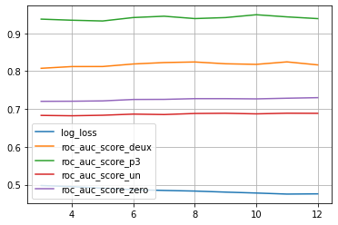

```python
max_depth_loss.plot()
plt.grid()
```

```python
max_depth_loss
```

|  | log_loss | roc_auc_score_deux | roc_auc_score_p3 | roc_auc_score_un | roc_auc_score_zero |
| --- | --- | --- | --- | --- | --- |
| 3 | 0.497908 | 0.807531 | 0.937429 | 0.683176 | 0.720315 |
| 4 | 0.494912 | 0.812151 | 0.934567 | 0.682207 | 0.720576 |
| 5 | 0.490888 | 0.812235 | 0.932552 | 0.683556 | 0.721478 |
| 6 | 0.487019 | 0.818974 | 0.941656 | 0.686579 | 0.725209 |
| 7 | 0.484937 | 0.822738 | 0.945146 | 0.685404 | 0.725471 |
| 8 | 0.483292 | 0.824254 | 0.938916 | 0.688242 | 0.727387 |
| 9 | 0.480533 | 0.819537 | 0.941553 | 0.688806 | 0.727389 |
| 10 | 0.478106 | 0.817947 | 0.949041 | 0.687209 | 0.726771 |
| 11 | 0.475325 | 0.824513 | 0.943419 | 0.688960 | 0.728521 |
| 12 | 0.475901 | 0.816566 | 0.938797 | 0.688657 | 0.730005 |

On privilégie l'entropie croisée car elle nous donne une mesure de proximité entre les valeurs prédites et les valeurs réelles, indiquant aisni la qualité de notre modèle.

```python
def plot_learning_curves(model, X_train, X_val, y_train, y_val):
    """ Plot the learning curves of the training set and the validation set for the given model.
    """
    train_errors, val_errors = [], []
    for m in range(1000, X_train.shape[0] + 1, 2000):
        model.fit(X_train[:m], y_train[:m])
        y_train_predict = model.predict_proba(X_train[:m])
        y_val_predict = model.predict_proba(X_val)
        #print(y_train_predict[0].shape)
        # print(len(y_train_predict))
        # print(y_train_predict)
        train_errors.append(log_loss(y_train[:m], y_train_predict))
        val_errors.append(log_loss(y_val, y_val_predict))
        # print(log_loss(y_val, y_val_predict))

    plt.plot(train_errors, 'r-+', linewidth=2, label='train')
    plt.plot(val_errors, 'b-', linewidth=3, label='val')
    plt.legend(loc="upper right")
    plt.xlabel("Training set size")
    plt.ylabel("log loss")
```

```python
simple_rfc = RandomForestClassifier(50, max_depth=3)

# plot_learning_curves(simple_rfc, np.array(X_train_claimNumber), np.array(X_val_claimNumber), np.array(y_train_claimNumber), np.array(y_val_claimNumber))
```

On retient quand même ce modèle que l'on comparera ensuite.

```python
rfc = RandomForestClassifier(n_estimators=500, max_depth=3)
rfc.fit(X_train_claimNumber, y_train_claimNumber)
y_val_pred_proba_CN = rfc.predict_proba(X_val_claimNumber)
y_val_pred_proba_CN[:3]
```

```
array([[0.02670214, 0.00788662, 0.15128064, 0.81413059],
       [0.01533402, 0.00353998, 0.11467477, 0.86645124],
       [0.01950833, 0.00507134, 0.12903565, 0.84638468]])
```

```python
np.save("models/claimNumber/prod/rfc_full_features_CN_val.npy", y_val_pred_proba_CN)
```

## Random Forest Classifier w/ Reduced Number of Features

Nous allons nous inspirer des études statistiques menées sour R afin de réduire le nombre de variables afin de voir si un tel modèle serait plus performant.

### Feature Engineering

```python
significative_subRegions_claimNumber = {"N8", "M4", "Q13", "Q24", "Q26", "R1", "R11", "R12", "R15", "R16", "R5", "R8", "L72"}


significative_subRegion_claimValue = {"L68", "L79", "L81", "L86", "O28", "P26", "P7", "S19", "S9"}
```

```python
def getSignificativeFeatures(row, significative_features, default_other="other"):
    """
    check if row is in significative_features (significative subRegion) and assigns default_other if not
    the goal here is to reduce the number of features
    """
    if row in significative_features:
        return row
    else: return default_other
```

```python
df_train["significativeSubRegion_claimNumber"] = df_train.subRegion.apply(
    lambda row: getSignificativeFeatures(
        row,
        significative_features=significative_subRegions_claimNumber
    )
)
df_train["significativeSubRegion_claimValue"] = df_train.subRegion.apply(
    lambda row: getSignificativeFeatures(
        row,
        significative_features=significative_subRegion_claimValue
    )
)
```

```python
cols_claimNumber = ["id", "gender", "carCategory", "occupation", "age", "carGroup", "bonus", "material", "cityDensity", "significativeSubRegion_claimNumber", "catClaimNumber"]
cols_claimValue = ["id", "gender", "carCategory", "age", "carGroup", "bonus", "material", "cityDensity", "significativeSubRegion_claimValue", "catClaimNumber", "claimValue"]
```

```python
df_train_reduced_claimNumber = df_train[cols_claimNumber]
df_train_reduced_claimValue = df_train[cols_claimValue]
# variables explicatives pour prédire claimValue (régression) et catClaimNumber (classification)
X_train_reduced_claimValue = df_train_reduced_claimValue[:50000].drop(columns=['id', 'claimValue'])
X_train_reduced_claimNumber = df_train_reduced_claimNumber[:50000].drop(columns=['id', 'catClaimNumber'])

# Validation set
X_val_reduced_claimValue = df_train_reduced_claimValue[50000:].drop(columns=['id', 'claimValue'])
X_val_reduced_claimNumber = df_train_reduced_claimNumber[50000:].drop(columns=['id', 'catClaimNumber'])
```

```python
X_train_reduced_claimNumber, X_val_reduced_claimNumber = pd.get_dummies(X_train_reduced_claimNumber), pd.get_dummies(X_val_reduced_claimNumber)
X_train_reduced_claimValue, X_val_reduced_claimValue = pd.get_dummies(X_train_reduced_claimValue), pd.get_dummies(X_val_reduced_claimValue)
```

Nous avons réaliser une GridSearchCV (exploration des hyperparamètres optimaux) dans un autre notebook (improved_CART_models.ipynb) qui nous a donné la combinaison de paramètres suivant.

### Modèle

```python
rfc_reduced = RandomForestClassifier(n_estimators=1000, max_depth=7)
rfc_reduced.fit(X_train_reduced_claimNumber, y_train_claimNumber)

y_val_reduced_pred_proba_CN = rfc_reduced.predict_proba(X_val_reduced_claimNumber)
```

```python
print(f"Score d'entropie croisée pour le premier rfc avec toutes les features: {log_loss(y_val_claimNumber, y_val_pred_proba_CN):.3f}")
print(f"Score d'entropie croisée pour le second rfc avec réduction de features: {log_loss(y_val_claimNumber, y_val_reduced_pred_proba_CN):.3f}")
```

```
Score d'entropie croisée pour le premier rfc avec toutes les features: 0.498
Score d'entropie croisée pour le second rfc avec réduction de features: 0.464
```

```python
np.save("models/claimNumber/prod/rfc_reduced_CV.npy", y_val_reduced_pred_proba_CN)
```

Ces deux modèles sont très mauvais en simple prédiction comme le montre ce tableau.

```python
from sklearn.metrics import classification_report

y_val_reduced_pred_CN = rfc_reduced.predict(X_val_reduced_claimNumber)
print(classification_report(y_val_reduced_pred_CN, y_val_claimNumber))
```

```
              precision    recall  f1-score   support

        deux       0.00      0.00      0.00         0
          p3       0.00      0.00      0.00         0
          un       0.00      0.00      0.00         0
        zero       1.00      0.84      0.91     10000

    accuracy                           0.84     10000
   macro avg       0.25      0.21      0.23     10000
weighted avg       1.00      0.84      0.91     10000
```

Il prédit que tout les individus auront zéro sinistre ! C'est pourquoi nous préférerons travailler avec les probabilités d'appartenir à une classe.

```python
y_val_reduced_pred_proba_CN[:3]
```

```
array([[4.17557813e-02, 8.96705828e-03, 2.05720013e-01, 7.43557147e-01],
       [4.78853084e-03, 3.61481849e-04, 7.56071308e-02, 9.19242856e-01],
       [1.19167896e-02, 1.63990471e-03, 1.07349157e-01, 8.79094149e-01]])
```

Notre modèle avec réduction de variables est plus performant !  
Essayons de voir si un XGBoost peut faire encore mieux !

```python
y_train_reduced_pred_proba_CN = rfc_reduced.predict_proba(X_train_reduced_claimNumber)
```

## XGBoost

On va utiliser des paramètres par défault mais l'idéal serait de trouver les hyper paramètres optimaux à l'aide d'un GridSearch

```python
from xgboost import XGBClassifier
from sklearn.preprocessing import LabelEncoder

le = LabelEncoder()  # encode 1D class to 4D single classes, easier to use with inverse_transform

xgb = XGBClassifier(max_depth=7, n_estimators=750)
xgb.fit(X_train_reduced_claimNumber, le.fit_transform(y_train_claimNumber))
```

```python
y_val_reduced_pred_proba_xgb_CN = xgb.predict_proba(X_val_reduced_claimNumber)
y_val_reduced_pred_xgb_CN = xgb.predict(X_val_reduced_claimNumber)
```

```python
y_val_reduced_pred_proba_xgb_CN[:3]
```

```
array([[2.3172467e-03, 3.4464600e-05, 3.5325855e-01, 6.4438975e-01],
       [2.8707378e-05, 3.1420118e-08, 1.0547986e-02, 9.8942333e-01],
       [3.2395179e-05, 1.3313071e-07, 4.4752397e-03, 9.9549222e-01]],
      dtype=float32)
```

```python
np.save("models/claimNumber/prod/xgb_reduced_proba.npy", y_val_reduced_pred_proba_xgb_CN)
np.save("models/claimNumber/prod/xgb_reduced.npy", le.inverse_transform(y_val_reduced_pred_xgb_CN))
```

```python
print(classification_report(le.inverse_transform(y_val_reduced_pred_xgb_CN), y_val_claimNumber))
```

```
              precision    recall  f1-score   support

        deux       0.04      0.16      0.06        50
          p3       0.12      0.26      0.16        19
          un       0.10      0.28      0.15       482
        zero       0.96      0.86      0.91      9449

    accuracy                           0.82     10000
   macro avg       0.30      0.39      0.32     10000
weighted avg       0.91      0.82      0.86     10000
```

```python
print(f"Score d'entropie croisée pour le premier rfc avec toutes les features: {log_loss(y_val_claimNumber, y_val_pred_proba_CN):.3f}")
print(f"Score d'entropie croisée pour le second rfc avec réduction de features: {log_loss(y_val_claimNumber, y_val_reduced_pred_proba_CN):.3f}")
print(f"Score d'entropie croisée pour le xgb avec réduction de features: {log_loss(y_val_claimNumber, y_val_reduced_pred_proba_xgb_CN):.3f}")
```

```
Score d'entropie croisée pour le premier rfc avec toutes les features: 0.499
Score d'entropie croisée pour le second rfc avec réduction de features: 0.463
Score d'entropie croisée pour le xgb avec réduction de features: 0.618
```

Après avoir réalisé une GridSearchCV sur l'espace des hyper paramètres, nous avons obtenus le XGBoost Classifier suivant, qui surperforme les précédents modèles.  
Nous utilisons toutes les modalités, le modèle se chargera d'isoler celle qu'il trouve les plus pertinente.

#### XGBoost avec toutes les variables et de meilleurs hyper paramètres

```python
xgb_clf_best = XGBClassifier(n_estimators=100, max_depth=3, eta=.1, subsample=.7)
xgb_clf_best.fit(X_train_claimNumber, le.fit_transform(y_train_claimNumber))
y_val_pred_proba_xgb_best_CN = xgb_clf_best.predict_proba(X_val_claimNumber)
y_val_pred_xgb_best_CN = xgb_clf_best.predict(X_val_claimNumber)
```

```python
print(classification_report(le.inverse_transform(y_val_pred_xgb_best_CN), y_val_claimNumber, zero_division=0))
print(f"Score d'entropie croisée pour le xgb avec réduction de features: {log_loss(y_val_claimNumber, y_val_pred_proba_xgb_best_CN):.3f}")
```

```
              precision    recall  f1-score   support

        deux       0.00      0.00      0.00         0
          p3       0.02      1.00      0.05         1
          un       0.01      0.32      0.01        25
        zero       1.00      0.84      0.92      9974

    accuracy                           0.84     10000
   macro avg       0.26      0.54      0.24     10000
weighted avg       1.00      0.84      0.91     10000

Score d'entropie croisée pour le xgb avec réduction de features: 0.457
```

Le score d'entropie croisée est plus faible que celui des précédents modèles. De plus, la classe `zero` est prédite avec 100 % de précision, i.e., il n'y a pas de faux positifs (assurés ayant plus d'un sinistre mais prédit à zéro.).  
Cependant, les très faibles précisions des modalités `un` et `deux` ainsi que un recall de 0.84 pour la modalité `zero` indiquent que la plupart des individus prédits à `un` ou `p3` sont en réalité des bons risques à `zero`. On ferait donc payer à ces individus une prime plus cher que ce qu'elle devrait être, ce qui n'est pas forcèment une bonne stratégie et entraînerait de l'antisélection.

Cet example illustre en fait très bien l'importance du choix de la métrique d'évaluation du modèle selon le problème à résoudre. Bien que l'entropie croisée du xgboost soit plus faible que celle du Random Forest, celui-ci n'est pas meilleur pour notre critère de choix. Par exemple, bien qu'il ait correctement prédit la seule personne de classe `p3` ( $Recall(p3) = 1$ ), il a prédit 59 autres individus qui eux ne sont pas de cette classe. ( $Precision(p3) * n = Support(p3)$ )

Ainsi, nous choisissons de garder les prédictions du Random Forest dont les features ont été réduites.

# II - Modèles de Regression

Maintenant que nous avons prédit des probabilité de nombre d'accidents à l'année pour chaque assuré, nous pouvons nous intéresser aux montants de ces sinistres.

Comme le nombre de sinistre est fortement corrélé au montant des sinistres, il est pertinent de réaliser des modèles prenant en compte cette variable prédite, chose que nous ferons par la suite.

- [ ] AJOUTER GLM SUR claimValue ~ catClaimNumber (4 classes !) + autre variables utilisées ici pour montrer la significativité. !!! enlever les non sinistrés !!!

Afin d'avoir une idée des primes d'un assuré, nous pouvons calculer la moyenne des claimValue par groupe de nombre de sinistre pondéré par les probabilitié pour cete individu d'appartenir à tel groupe.

```python
# On récupère les ids des individus utilisés dans le train set
df_train_train = df_train[df_train.id.isin(X_train_ids.values.tolist())]
train_stats = get_stats(df_train_train)
train_stats
```

```
{'Means': Means(pp=313.05579511689916, pp1=1720.096566696565, pp2=3255.0009497849665, pp3=4661.237644256584),
 'Medians': Medians(med=0.0, med1=583.7777, med2=1490.5175, med3=2802.33),
 'Stds': Stds(std=1818.4372927945801, std1=3764.322735822085, std2=5769.7640732584005, std3=5910.873455518021),
 'Skewness': Skewness(skn=12.710479086457537, skn1=5.248374237850162, skn2=4.86140796340139, skn3=3.653673024789614),
 'Kurtosis': Kurtosis(kts=224.07078625731296, kts1=36.632760212491476, kts2=30.770714909672044, kts3=16.61907888434291),
 'Effectifs': Effectifs(c0=42280, c1=6431, c2=1008, c3=281)}
```

```python
train_stats_means = train_stats["Means"]
train_means_array = np.array([train_stats_means.pp2, train_stats_means.pp3, train_stats_means.pp1, 0])  # dans cet ordre à cause du p.s.

y_val_reduced_pred_proba_CN[1].dot(train_means_array)
```

```
145.05990394866362
```

```python
def get_premium_from_weighted_group_average(claimNumber_class_probas, group_premium_avg):
    """Compute individual premium based on predicted probabilities of being in catClaimNumber
    and those group's premium average.

    Args:
        claimNumber_class_probas (np.array[n, 4]): predictions (`deux`, `p3`, `un`, `zero`)
        group_premium_avg (np.array[4, 1]): average premiums by group (pp2, pp3, pp1, 0)

    Returns:
        np.array[n, 1] : individual premium estimation
    """
    return np.dot(claimNumber_class_probas, np.reshape(group_premium_avg, (-1, 1)))
```

```python
y_val_reduced_premiums_weighted = get_premium_from_weighted_group_average(y_val_reduced_pred_proba_CN, train_means_array)
print(f"Mean on validation set: {y_val_reduced_premiums_weighted.mean():.3f}")
# print(f"Median: {y_val_reduced_premiums_weighted.median()}")
print(f"Standard Deviation on validation set: {y_val_reduced_premiums_weighted.std():.3f}")
```

```
Mean on validation set: 313.091
Standard Deviation on validation set: 199.138
```

```python
y_train_reduced_premiums_weighted = get_premium_from_weighted_group_average(y_train_reduced_pred_proba_CN, train_means_array)
print(f"Mean on training set: {y_train_reduced_premiums_weighted.mean():.3f}")
# print(f"Median: {y_train_reduced_premiums_weighted.median()}")
print(f"Standard Deviation on training set: {y_train_reduced_premiums_weighted.std():.3f}")
```

```
Mean on training set: 312.784
Standard Deviation on training set: 200.085
```

```python
stats_whole_train
```

```
{'Means': Means(pp=315.36840116253376, pp1=1747.1658587632858, pp2=3199.1425559483996, pp3=4611.173088074383),
 'Medians': Medians(med=0.0, med1=583.56435, med2=1453.741, med3=2732.182),
 'Stds': Stds(std=1873.5753287755952, std1=3983.028525415896, std2=5688.137867404405, std3=5939.797270756158),
 'Skewness': Skewness(skn=13.317095386328154, skn1=5.8139537324633075, skn2=4.794976274870123, skn3=3.702195151434647),
 'Kurtosis': Kurtosis(kts=249.96339750217766, kts1=48.20631352835252, kts2=29.86799202403963, kts3=16.705532979081273),
 'Effectifs': Effectifs(c0=50709, c1=7754, c2=1213, c3=324)}
```

On remarque par exemple que la prime pure est plus faible de 3 € sur le validation set...

- [ ] Essayer de fit les montants prédits en val par rapport aux montnats du training pour voir si ils sont cohérents ?

```python
# On ajoute ensuite le bonus-malus:
df_val = df_train[df_train.id.isin(X_val_ids.values.tolist())]

y_val_reduced_premiums_weighted_final = y_val_reduced_premiums_weighted.reshape(10000, ) + df_val.bonus.values
```

```python
y_val_reduced_premiums_weighted_final
```

```
array([552.56385791,  95.05990395, 213.72571677, ..., 246.72252254,
       115.86541547, 540.70180932])
```

```python
y_train_reduced_premiums_weighted_final = y_train_reduced_premiums_weighted.reshape(50000, ) + df_train_train.bonus.values
```

```python
np.save("models/premiums/y_val_reduced_rfc_premium_weighted_by_group_final", y_val_reduced_premiums_weighted_final)
```

```python
y_val_reduced_premiums_weighted_final.mean()
```

```
306.5696418750007
```

```python
y_train_reduced_premiums_weighted_final.mean()
```

```
305.6735234909396
```

L'ajout des bonus malus a permit de réduire la prime moyenne.

```python
df_val["finalPremium_rfc_reduced_weighted_by_group"] = y_val_reduced_premiums_weighted_final
```

QQ Plot du montant des sinistres et des primes prédites sur le validation set en utilisant les nombres de sinistre prédits par random forest classifier reduced

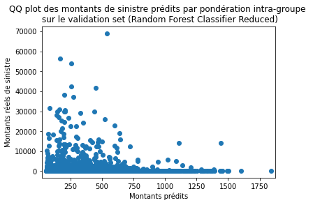

```python
from statsmodels.graphics.gofplots import qqplot_2samples
import statsmodels.api as sm

pp_predictions = sm.ProbPlot(y_val_reduced_premiums_weighted)
pp_claimValues = sm.ProbPlot(df_val.claimValue.values)
qqplot_2samples(pp_predictions, pp_claimValues, xlabel="Montants prédits", ylabel="Montants réels de sinistre")
plt.title("QQ plot des montants de sinistre prédits par pondération intra-groupe \n sur le validation set (Random Forest Classifier Reduced)")
```

Calcul du bilan: somme des primes - somme des sinistres

```python
y_val_reduced_premiums_weighted_final.sum() - df_val.claimValue.values.sum()
```

```
-203617.8951570643
```

Mauvais signe pour l'assureur !

sur le training set

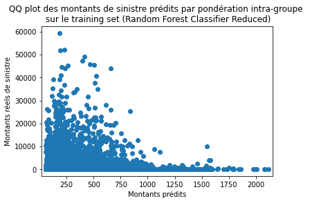

```python
pp_predictions = sm.ProbPlot(y_train_reduced_premiums_weighted)
pp_claimValues = sm.ProbPlot(df_train_train.claimValue.values)
qqplot_2samples(pp_predictions, pp_claimValues, xlabel="Montants prédits", ylabel="Montants réels de sinistre")
plt.title("QQ plot des montants de sinistre prédits par pondération intra-groupe \n sur le training set (Random Forest Classifier Reduced)")
```

Analysons la performance de ce modèle regressif à l'aide de différentes metriques.

```python
from sklearn.metrics import r2_score, median_absolute_error, mean_absolute_error
#training set
print(f"Prédictions du montant des sinistres sur training set:\
\n- R²: {r2_score(df_train_train.claimValue.values, y_train_reduced_premiums_weighted)}\
\n- MAE (perte l1): {mean_absolute_error(df_train_train.claimValue.values, y_train_reduced_premiums_weighted)}\
\n-  Median Absolute Error: {median_absolute_error(df_train_train.claimValue.values, y_train_reduced_premiums_weighted)}")
print()
# validation set
print(f"Prédictions du montant des sinistres sur validation set:\
\n- R²: {r2_score(df_val.claimValue.values, y_val_reduced_premiums_weighted)}\
\n- MAE (perte l1): {mean_absolute_error(df_val.claimValue.values, y_val_reduced_premiums_weighted)}\
\n-  Median Absolute Error: {median_absolute_error(df_val.claimValue.values, y_val_reduced_premiums_weighted)}")
```

```
Prédictions du montant des sinistres sur training set:
- R²: 0.02484904374515906
- MAE (perte l1): 510.0575261869437
-  Median Absolute Error: 239.69559951351573

Prédictions du montant des sinistres sur validation set:
- R²: 0.010875394327770405
- MAE (perte l1): 528.4308032378761
-  Median Absolute Error: 240.34173783108218
```

Ces résultats confirment ce que l'on pouvait déjà voir sur le QQ plot, le modèle est très mauvais.

### Consolidation de fichiers

```python
df_val.columns
```

```
Index(['id', 'gender', 'carType', 'carCategory', 'occupation', 'age',
       'carGroup', 'bonus', 'carValue', 'material', 'subRegion', 'region',
       'cityDensity', 'catClaimNumber', 'claimValue',
       'significativeSubRegion_claimNumber',
       'significativeSubRegion_claimValue',
       'finalPremium_rfc_reduced_weighted_by_group'],
      dtype='object')
```

```python
y_val_reduced_pred_proba_CN
```

```
array([[4.14946621e-02, 8.86750314e-03, 2.07061139e-01, 7.42576696e-01],
       [4.62279227e-03, 3.10297254e-04, 7.47436766e-02, 9.20323234e-01],
       [1.12597119e-02, 1.49345611e-03, 1.04711557e-01, 8.82535275e-01],
       ...,
       [1.38505408e-02, 1.82432362e-03, 1.18095342e-01, 8.66229793e-01],
       [6.47547760e-03, 5.82293145e-04, 8.25962482e-02, 9.10345981e-01],
       [4.20824801e-02, 9.08251699e-03, 2.10097231e-01, 7.38737771e-01]])
```

```python
df_val[["proba_deux_rfc_reduced", "proba_p3_rfc_reduced", "proba_un_rfc_reduced", "proba_zero_rfc_reduced"]] = y_val_reduced_pred_proba_CN
df_val["premium_rfc_reduced_weighted_by_group_no_BM"] = y_val_reduced_premiums_weighted
```

```python
df_val["finalPremium_rfc_reduced_weighted_by_group_PP_added"] = df_val.finalPremium_rfc_reduced_weighted_by_group + train_stats["Means"].pp
```

```python
df_val.head()
```

|  | id | gender | carType | carCategory | occupation | age | carGroup | bonus | carValue | material | ... | claimValue | significativeSubRegion_claimNumber | significativeSubRegion_claimValue | finalPremium_rfc_reduced_weighted_by_group | proba_deux_rfc_reduced | proba_p3_rfc_reduced | proba_un_rfc_reduced | proba_zero_rfc_reduced | premium_rfc_reduced_weighted_by_group_no_BM | finalPremium_rfc_reduced_weighted_by_group_PP_added |
| --- | --- | --- | --- | --- | --- | --- | --- | --- | --- | --- | --- | --- | --- | --- | --- | --- | --- | --- | --- | --- | --- |
| 3675 | 3676 | Female | C | Small | Housewife | 19 | 18 | 20 | 26685 | 0 | ... | 0.000 | other | other | 552.563858 | 0.041495 | 0.008868 | 0.207061 | 0.742577 | 532.563858 | 865.619653 |
| 15450 | 15451 | Male | A | Medium | Employed | 60 | 9 | -50 | 26830 | 1 | ... | 0.000 | other | other | 95.059904 | 0.004623 | 0.000310 | 0.074744 | 0.920323 | 145.059904 | 408.115699 |
| 20608 | 20609 | Female | E | Medium | Housewife | 49 | 10 | -10 | 8740 | 0 | ... | 0.000 | other | other | 213.725717 | 0.011260 | 0.001493 | 0.104712 | 0.882535 | 223.725717 | 526.781512 |
| 46531 | 46532 | Female | E | Medium | Employed | 24 | 13 | 30 | 20505 | 1 | ... | 2472.103 | other | other | 517.113799 | 0.035283 | 0.009163 | 0.191591 | 0.763963 | 487.113799 | 830.169594 |
| 6749 | 6750 | Male | F | Large | Unemployed | 39 | 11 | 40 | 25135 | 1 | ... | 0.000 | other | other | 405.914733 | 0.022338 | 0.005754 | 0.154867 | 0.817042 | 365.914733 | 718.970529 |

5 rows × 24 columns

`finalPremium_rfc_reduced_weighted_by_group_PP_added` correspond à la prime prédite à laquelle on a ajouté la prime moyenne obtenue dans les statistiques du train set. La prime résultante sera en général trop élevé, cependant, elle permettra à l'assureur de réaliser un bilan posiitf et nous servira donc de point de départ.

```python
# résultat de l'assureur
df_val.finalPremium_rfc_reduced_weighted_by_group_PP_added.sum() - df_val.claimValue.sum()
```

```
2926940.0560119273
```

```python
df_train_train.columns
```

```
Index(['id', 'gender', 'carType', 'carCategory', 'occupation', 'age',
       'carGroup', 'bonus', 'carValue', 'material', 'subRegion', 'region',
       'cityDensity', 'catClaimNumber', 'claimValue',
       'significativeSubRegion_claimNumber',
       'significativeSubRegion_claimValue'],
      dtype='object')
```

```python
df_train_train[["proba_deux_rfc_reduced", "proba_p3_rfc_reduced", "proba_un_rfc_reduced", "proba_zero_rfc_reduced"]] = y_train_reduced_pred_proba_CN
df_train_train["premium_rfc_reduced_weighted_by_group_no_BM"] = y_train_reduced_premiums_weighted
df_train_train["finalPremium_rfc_reduced_weighted_by_group"] = y_train_reduced_premiums_weighted_final
df_train_train["finalPremium_rfc_reduced_weighted_by_group_PP_added"] = df_train_train.finalPremium_rfc_reduced_weighted_by_group + train_stats["Means"].pp
```

```python
df_train_train.head()
```

|  | id | gender | carType | carCategory | occupation | age | carGroup | bonus | carValue | material | ... | claimValue | significativeSubRegion_claimNumber | significativeSubRegion_claimValue | proba_deux_rfc_reduced | proba_p3_rfc_reduced | proba_un_rfc_reduced | proba_zero_rfc_reduced | premium_rfc_reduced_weighted_by_group_no_BM | finalPremium_rfc_reduced_weighted_by_group | finalPremium_rfc_reduced_weighted_by_group_PP_added |
| --- | --- | --- | --- | --- | --- | --- | --- | --- | --- | --- | --- | --- | --- | --- | --- | --- | --- | --- | --- | --- | --- |
| 12628 | 12629 | Female | B | Medium | Self-employed | 22 | 3 | -20 | 15830 | 1 | ... | 0.0 | M4 | other | 0.032861 | 0.011590 | 0.152621 | 0.802929 | 423.505200 | 403.505200 | 716.560996 |
| 37730 | 37731 | Male | C | Large | Unemployed | 63 | 5 | -30 | 12675 | 1 | ... | 0.0 | other | other | 0.005204 | 0.000518 | 0.079916 | 0.914363 | 156.814196 | 126.814196 | 439.869991 |
| 39991 | 39992 | Male | B | Medium | Unemployed | 37 | 13 | 60 | 15980 | 0 | ... | 35062.1 | other | other | 0.031074 | 0.007483 | 0.179858 | 0.781585 | 445.397248 | 505.397248 | 818.453043 |
| 8525 | 8526 | Male | B | Medium | Unemployed | 41 | 13 | -40 | 15345 | 1 | ... | 0.0 | other | other | 0.008093 | 0.001021 | 0.098708 | 0.892177 | 200.892204 | 160.892204 | 473.947999 |
| 8279 | 8280 | Female | E | Large | Unemployed | 22 | 9 | 60 | 16385 | 1 | ... | 0.0 | other | other | 0.033082 | 0.009589 | 0.172969 | 0.784360 | 449.903147 | 509.903147 | 822.958942 |

5 rows × 24 columns

```python
df_train_train.to_csv('data/training_results.csv', index=False)
df_val.to_csv('data/validation_results.csv', index=False)
```

## XGB Regression

On va chercher à prédire le montant des sinistres pour chaque individus ayant au moins un sinistre. Un GridSearchCV sur un autre notebook nous a permit de trouver les hyper paramètres optimaux de l'estimateur suivant.

```python
from xgboost import XGBRegressor

xgb_claimValue = XGBRegressor(n_estimators=100, max_depth=3, eta=1, subsample=1)
```

```python
xgb_claimValue.fit(X_train_claimValue, y_train_claimValue)
```

```
XGBRegressor(base_score=0.5, booster='gbtree', callbacks=None,
             colsample_bylevel=1, colsample_bynode=1, colsample_bytree=1,
             early_stopping_rounds=None, enable_categorical=False, eta=1,
             eval_metric=None, feature_types=None, gamma=0, gpu_id=-1,
             grow_policy='depthwise', importance_type=None,
             interaction_constraints='', learning_rate=1, max_bin=256,
             max_cat_threshold=64, max_cat_to_onehot=4, max_delta_step=0,
             max_depth=3, max_leaves=0, min_child_weight=1, missing=nan,
             monotone_constraints='()', n_estimators=100, n_jobs=0,
             num_parallel_tree=1, predictor='auto', ...)
```

```python
y_val_pred_xgb_claimValue_GT_CN = xgb_claimValue.predict(X_val_claimValue)
y_train_pred_xgb_claimValue_GT_CN = xgb_claimValue.predict(X_train_claimValue)
```

```python
y_val_pred_xgb_claimValue_GT_CN[:3]
```

```
array([-42.700653, -83.64165 ,  23.238764], dtype=float32)
```

On obtient des valeurs négatives... Pour remédier à cela, nous allons transformer les montants de sinistres ainsi : $\tilde{Y} = \log(Y + 1)$.

Les prédictions se feront sur $\tilde{Y}$ et la transformée inverse $Y = e^{\tilde{Y}} - 1$ sera (presque) positive.

```python
y_train_claimValue_log = np.log(y_train_claimValue + 1)
y_train_claimValue_log[:3]
```

```
12628     0.000000
37730     0.000000
39991    10.464905
Name: claimValue, dtype: float64
```

```python
xgb_log_claimValue = XGBRegressor(n_estimators=100, max_depth=3, eta=1, subsample=1)
xgb_log_claimValue.fit(X_train_claimValue, y_train_claimValue_log)
y_val_pred_xgb_claimValue_log_GT_CN = xgb_claimValue.predict(X_val_claimValue)
```

```python
y_val_pred_xgb_claimValue_log_transformed_GT_CN = np.exp(y_val_pred_xgb_claimValue_log_GT_CN) - 1
y_val_pred_xgb_claimValue_log_transformed_GT_CN[:5]
```

[output not shown]

```python
y_train_pred_xgb_claimValue_log_GT_CN = xgb_log_claimValue.predict(X_train_claimValue)
y_train_pred_xgb_claimValue_log_transformed_GT_CN = np.exp(y_train_pred_xgb_claimValue_log_GT_CN) - 1
```

## Résultats

### Modèle régressif avec nombre réel de sinistres

#### Interprétation du modèle sur le training set :

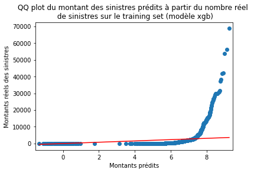

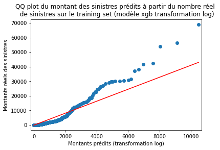

```python
pp_predictions_train_log = sm.ProbPlot(y_train_pred_xgb_claimValue_log_transformed_GT_CN)
pp_predictions_train = sm.ProbPlot(y_train_pred_xgb_claimValue_GT_CN)
pp_claimValues_train = sm.ProbPlot(df_train_train.claimValue.values)
qqplot_2samples(pp_predictions_train, pp_claimValues, line='r', xlabel="Montants prédits", ylabel="Montants réels des sinistres")
plt.title("QQ plot du montant des sinistres prédits à partir du nombre réel \n de sinistres sur le training set (modèle xgb)")

qqplot_2samples(pp_predictions_train_log, pp_claimValues, line='r', xlabel="Montants prédits (transformation log)", ylabel="Montants réels des sinistres")
plt.title("QQ plot du montant des sinistres prédits à partir du nombre réel \n de sinistres sur le training set (modèle xgb transformation log)")
```

On observe qu'en passant par une transformation log, notre modèle se rapproche bien plus de la distribution théorique du montant des sinistres, bien qu'il a encore du mal à expliquer les valeurs extrêmes à droites (tout simplement car il s'agit d'une distribution différente).

#### Analyse des prédictions sur le validation set

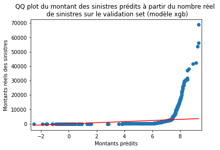

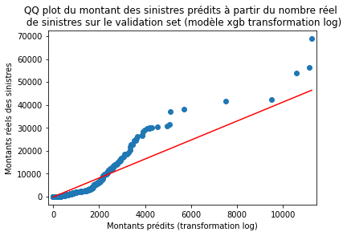

```python
pp_predictions = sm.ProbPlot(y_val_pred_xgb_claimValue_GT_CN)
pp_claimValues = sm.ProbPlot(df_val.claimValue.values)
qqplot_2samples(pp_predictions, pp_claimValues, line='r', xlabel="Montants prédits", ylabel="Montants réels des sinistres")
plt.title("QQ plot du montant des sinistres prédits à partir du nombre réel \n de sinistres sur le validation set (modèle xgb)")

pp_predictions_log = sm.ProbPlot(y_val_pred_xgb_claimValue_log_transformed_GT_CN)
qqplot_2samples(pp_predictions_log, pp_claimValues, line='r', xlabel="Montants prédits (transformation log)", ylabel="Montants réels des sinistres")
plt.title("QQ plot du montant des sinistres prédits à partir du nombre réel \n de sinistres sur le validation set (modèle xgb transformation log)")
```

Interprétation

```python
#training set
print(f"Prédictions du montant des sinistres sur training set (modèle xgb avec nombre réel de sinistre):\
\n- R²: {r2_score(df_train_train.claimValue.values, y_train_pred_xgb_claimValue_GT_CN)}\
\n- MAE (perte l1): {mean_absolute_error(df_train_train.claimValue.values, y_train_pred_xgb_claimValue_GT_CN)}\
\n-  Median Absolute Error: {median_absolute_error(df_train_train.claimValue.values, y_train_pred_xgb_claimValue_GT_CN)}")
print()
print(f"Prédictions du montant des sinistres sur training set (modèle xgb avec nombre réel de sinistre et transformation log):\
\n- R²: {r2_score(df_train_train.claimValue.values, y_train_pred_xgb_claimValue_log_transformed_GT_CN)}\
\n- MAE (perte l1): {mean_absolute_error(df_train_train.claimValue.values, y_train_pred_xgb_claimValue_log_transformed_GT_CN)}\
\n-  Median Absolute Error: {median_absolute_error(df_train_train.claimValue.values, y_train_pred_xgb_claimValue_log_transformed_GT_CN)}")
print()
# validation set
print(f"Prédictions du montant des sinistres sur validation set (modèle xgb avec nombre réel de sinistre):\
\n- R²: {r2_score(df_val.claimValue.values, y_val_pred_xgb_claimValue_GT_CN)}\
\n- MAE (perte l1): {mean_absolute_error(df_val.claimValue.values, y_val_pred_xgb_claimValue_GT_CN)}\
\n-  Median Absolute Error: {median_absolute_error(df_val.claimValue.values, y_val_pred_xgb_claimValue_GT_CN)}")
print()
print(f"Prédictions du montant des sinistres sur validation set (modèle xgb avec nombre réel de sinistre et transformation log):\
\n- R²: {r2_score(df_val.claimValue.values, y_val_pred_xgb_claimValue_log_transformed_GT_CN)}\
\n- MAE (perte l1): {mean_absolute_error(df_val.claimValue.values, y_val_pred_xgb_claimValue_log_transformed_GT_CN)}\
\n-  Median Absolute Error: {median_absolute_error(df_val.claimValue.values, y_val_pred_xgb_claimValue_log_transformed_GT_CN)}")
print()
```

```
Prédictions du montant des sinistres sur training set (modèle xgb avec nombre réel de sinistre):
- R²: -0.028321333164588403
- MAE (perte l1): 312.0909597779091
-  Median Absolute Error: 0.01522267609834671

Prédictions du montant des sinistres sur training set (modèle xgb avec nombre réel de sinistre et transformation log):
- R²: 0.18881975045130128
- MAE (perte l1): 242.39242235817983
-  Median Absolute Error: 0.01531517505645752

Prédictions du montant des sinistres sur validation set (modèle xgb avec nombre réel de sinistre):
- R²: -0.02265350249082254
- MAE (perte l1): 325.95404109620836
-  Median Absolute Error: 0.015763447619974613

Prédictions du montant des sinistres sur validation set (modèle xgb avec nombre réel de sinistre et transformation log):
- R²: 0.0763475848639672
- MAE (perte l1): 282.7734960792232
-  Median Absolute Error: 0.015780746936798096
```

On retient que la transformation log permet un meilleur fit, avec des scores R² plus élevés.

### Modèle régressif avec nombre prédit de sinistres

La prédiction sera ensuite la pondération des résultats obtenus par les probabilités : $$ \hat{P_i} = \hat{Y}|\mathbf{x_i} = \begin{pmatrix} \hat{Y}|x_i^{deux} & \hat{Y}|x_i^{p3} & \hat{Y}|x_i^{un} & \hat{Y}|x_i^{zero} \end{pmatrix} \begin{pmatrix} p_i^{deux} \\ p_i^{p3} \\ p_i^{un} \\ p_i^{zero} \end{pmatrix} $$

```python
X_val_claimValue_copy_zero, X_val_claimValue_copy_un, X_val_claimValue_copy_deux, X_val_claimValue_copy_p3 = X_val_claimValue.copy(), X_val_claimValue.copy(), X_val_claimValue.copy(), X_val_claimValue.copy()
X_val_claimValue_copy_zero[["catClaimNumber_deux", "catClaimNumber_p3", "catClaimNumber_un", "catClaimNumber_zero"]] = 0
X_val_claimValue_copy_zero.catClaimNumber_zero = 1
X_val_claimValue_copy_un[["catClaimNumber_deux", "catClaimNumber_p3", "catClaimNumber_un", "catClaimNumber_zero"]] = 0
X_val_claimValue_copy_un.catClaimNumber_un = 1
X_val_claimValue_copy_deux[["catClaimNumber_deux", "catClaimNumber_p3", "catClaimNumber_un", "catClaimNumber_zero"]] = 0
X_val_claimValue_copy_deux.catClaimNumber_deux = 1
X_val_claimValue_copy_p3[["catClaimNumber_deux", "catClaimNumber_p3", "catClaimNumber_un", "catClaimNumber_zero"]] = 0
X_val_claimValue_copy_p3.catClaimNumber_p3 = 1
```

```python
y_val_pred_xgb_claimValue_log_transformed_GT_predicted_CN_copy_zero = np.exp(xgb_log_claimValue.predict(X_val_claimValue_copy_zero))- 1
y_val_pred_xgb_claimValue_log_transformed_GT_predicted_CN_copy_un = np.exp(xgb_log_claimValue.predict(X_val_claimValue_copy_un)) - 1
y_val_pred_xgb_claimValue_log_transformed_GT_predicted_CN_copy_deux = np.exp(xgb_log_claimValue.predict(X_val_claimValue_copy_deux)) - 1
y_val_pred_xgb_claimValue_log_transformed_GT_predicted_CN_copy_p3 = np.exp(xgb_log_claimValue.predict(X_val_claimValue_copy_p3)) - 1
```

```python
y_val_pred_xgb_claimValue_log_transformed_GT_predicted_CN_copy_p3, y_val_pred_xgb_claimValue_log_transformed_GT_predicted_CN_copy_deux, y_val_pred_xgb_claimValue_log_transformed_GT_predicted_CN_copy_un, y_val_pred_xgb_claimValue_log_transformed_GT_predicted_CN_copy_zero
```

```
(array([6720.492 , 1587.6119, 1666.5277, ..., 2054.1423, 3000.5059,
        4217.266 ], dtype=float32),
 array([1576.8248, 1737.5237, 1132.2085, ..., 1395.6215, 2038.7512,
        2126.6008], dtype=float32),
 array([ 486.7933 ,  513.0434 ,  338.80405, ...,  417.79105, 1767.0238 ,
         789.5757 ], dtype=float32),
 array([ 0.02475178,  0.15154707, -0.00111723, ...,  0.00077415,
         0.01994336, -0.03365791], dtype=float32))
```

On réalise le produit scalaire par ligne entre les matrices de probabilités et de montants de sinistres: $$ \begin{pmatrix} p_1^{zero} & \cdots & p_1^{p3} \\ \vdots & \ddots & \vdots \\ p_n^{zero} & \cdots & p_n^{p3} \end{pmatrix} \odot \begin{pmatrix} \hat{Y}|x_1^{zero} & \cdots & \hat{Y}|x_1^{p3} \\ \vdots & \ddots & \vdots \\ \hat{Y}|x_n^{zero} & \cdots & \hat{Y}|x_n^{p3} \end{pmatrix} = \begin{pmatrix} \hat{P_1} \\ \vdots \\ \hat{P_n} \end{pmatrix} $$

```python
# l'ordre est différent car les modalités ont été crées par ordre alphabétique avec `get_dummies()`
Y_val_pred_log_transformed_xgboost = np.array([
    y_val_pred_xgb_claimValue_log_transformed_GT_predicted_CN_copy_deux,
    y_val_pred_xgb_claimValue_log_transformed_GT_predicted_CN_copy_p3,
    y_val_pred_xgb_claimValue_log_transformed_GT_predicted_CN_copy_un,
    y_val_pred_xgb_claimValue_log_transformed_GT_predicted_CN_copy_zero]).T

Y_val_pred_log_transformed_xgboost
```

```
array([[ 1.5768248e+03,  6.7204922e+03,  4.8679330e+02,  2.4751782e-02],
       [ 1.7375237e+03,  1.5876119e+03,  5.1304340e+02,  1.5154707e-01],
       [ 1.1322085e+03,  1.6665277e+03,  3.3880405e+02, -1.1172295e-03],
       ...,
       [ 1.3956215e+03,  2.0541423e+03,  4.1779105e+02,  7.7414513e-04],
       [ 2.0387512e+03,  3.0005059e+03,  1.7670238e+03,  1.9943357e-02],
       [ 2.1266008e+03,  4.2172661e+03,  7.8957568e+02, -3.3657908e-02]],
      dtype=float32)
```

```python
# probas du Random Forest Classifier avec réduction du nombre de features
y_val_reduced_pred_proba_CN
```

```
array([[4.14946621e-02, 8.86750314e-03, 2.07061139e-01, 7.42576696e-01],
       [4.62279227e-03, 3.10297254e-04, 7.47436766e-02, 9.20323234e-01],
       [1.12597119e-02, 1.49345611e-03, 1.04711557e-01, 8.82535275e-01],
       ...,
       [1.38505408e-02, 1.82432362e-03, 1.18095342e-01, 8.66229793e-01],
       [6.47547760e-03, 5.82293145e-04, 8.25962482e-02, 9.10345981e-01],
       [4.20824801e-02, 9.08251699e-03, 2.10097231e-01, 7.38737771e-01]])
```

```python
y_val_pred_weighted_4_copies = np.sum(Y_val_pred_log_transformed_xgboost * y_val_reduced_pred_proba_CN, axis=1)
y_val_pred_weighted_4_copies[:5]
```

```
array([225.83815511,  47.01106463,  50.7129408 , 110.27040172,
       120.38635037])
```

Comme avoir une prime négative ne fait pas sens, on remplace toutes les primes négatives par 0.

```python
# résultat financier
print(f"Résultat financier sans ajout des BM: {y_val_pred_weighted_4_copies.sum() - df_val.claimValue.sum()}")
# ajout des BM
y_val_pred_weighted_4_copies_BM = y_val_pred_weighted_4_copies + df_val.bonus.values
print(f"Résultat financier avec ajout des BM: {y_val_pred_weighted_4_copies_BM.sum() - df_val.claimValue.sum()}")
# on enlève les résultats négatifs
y_val_pred_weighted_4_copies_no0 = np.maximum(0, y_val_pred_weighted_4_copies_BM)
print(f"Résultat financier sans primes négatives: {y_val_pred_weighted_4_copies_no0.sum() - df_val.claimValue.sum()}")
# ajout de la "prime collective" égale au montant de sinistre moyen du train set
y_val_pred_weighted_4_copies_BM_pp = y_val_pred_weighted_4_copies_BM + train_stats["Means"].pp
print(f"Résultat financier avec ajout des BM: {y_val_pred_weighted_4_copies_BM_pp.sum() - df_val.claimValue.sum()}")
```

```
Résultat financier sans ajout des BM: -1885553.0796530622
Résultat financier avec ajout des BM: -1950763.0796530624
Résultat financier sans primes négatives: -1936469.6378830373
Résultat financier avec ajout des BM: 1179794.8715159297
```

De même sur le training set

```python
X_train_claimValue_copy_zero, X_train_claimValue_copy_un, X_train_claimValue_copy_deux, X_train_claimValue_copy_p3 = X_train_claimValue.copy(), X_train_claimValue.copy(), X_train_claimValue.copy(), X_train_claimValue.copy()
X_train_claimValue_copy_zero[["catClaimNumber_deux", "catClaimNumber_p3", "catClaimNumber_un", "catClaimNumber_zero"]] = 0
X_train_claimValue_copy_zero.catClaimNumber_zero = 1
X_train_claimValue_copy_un[["catClaimNumber_deux", "catClaimNumber_p3", "catClaimNumber_un", "catClaimNumber_zero"]] = 0
X_train_claimValue_copy_un.catClaimNumber_un = 1
X_train_claimValue_copy_deux[["catClaimNumber_deux", "catClaimNumber_p3", "catClaimNumber_un", "catClaimNumber_zero"]] = 0
X_train_claimValue_copy_deux.catClaimNumber_deux = 1
X_train_claimValue_copy_p3[["catClaimNumber_deux", "catClaimNumber_p3", "catClaimNumber_un", "catClaimNumber_zero"]] = 0
X_train_claimValue_copy_p3.catClaimNumber_p3 = 1

y_train_pred_xgb_claimValue_log_transformed_GT_predicted_CN_copy_zero = np.exp(xgb_log_claimValue.predict(X_train_claimValue_copy_zero))- 1
y_train_pred_xgb_claimValue_log_transformed_GT_predicted_CN_copy_un = np.exp(xgb_log_claimValue.predict(X_train_claimValue_copy_un)) - 1
y_train_pred_xgb_claimValue_log_transformed_GT_predicted_CN_copy_deux = np.exp(xgb_log_claimValue.predict(X_train_claimValue_copy_deux)) - 1
y_train_pred_xgb_claimValue_log_transformed_GT_predicted_CN_copy_p3 = np.exp(xgb_log_claimValue.predict(X_train_claimValue_copy_p3)) - 1

Y_train_pred_log_transformed_xgboost = np.array([
    y_train_pred_xgb_claimValue_log_transformed_GT_predicted_CN_copy_deux,
    y_train_pred_xgb_claimValue_log_transformed_GT_predicted_CN_copy_p3,
    y_train_pred_xgb_claimValue_log_transformed_GT_predicted_CN_copy_un,
    y_train_pred_xgb_claimValue_log_transformed_GT_predicted_CN_copy_zero]).T


y_train_pred_weighted_4_copies = np.sum(Y_train_pred_log_transformed_xgboost * y_train_reduced_pred_proba_CN, axis=1)
y_train_pred_weighted_4_copies[:5]
```

```
array([273.19512129,  35.03651366, 375.86279061,  75.88113655,
        79.98611755])
```

```python
y_train_pred_weighted_4_copies_no0 = np.maximum(0, y_train_pred_weighted_4_copies_BM)
```

[output not shown]

```python
# résultat financier
print(f"Résultat financier (training set) sans ajout des BM: {y_train_pred_weighted_4_copies.sum() - df_train_train.claimValue.sum()}")
# ajout des BM
y_train_pred_weighted_4_copies_BM = y_train_pred_weighted_4_copies + df_train_train.bonus.values
print(f"Résultat financier (training set) avec ajout des BM: {y_train_pred_weighted_4_copies_BM.sum() - df_train_train.claimValue.sum()}")
# on enlève les résultats négatifs
y_train_pred_weighted_4_copies_no0 = np.maximum(0, y_train_pred_weighted_4_copies_BM)
print(f"Résultat financier sans primes négatives: {y_train_pred_weighted_4_copies_no0.sum() - df_train_train.claimValue.sum()}")
# ajout de la "prime collective" égale au montant de sinistre moyen du train set
y_train_pred_weighted_4_copies_BM_pp = y_train_pred_weighted_4_copies_BM + train_stats["Means"].pp
print(f"Résultat financier (training set) avec ajout des BM: {y_train_pred_weighted_4_copies_BM_pp.sum() - df_train_train.claimValue.sum()}")
```

```
Résultat financier (training set) sans ajout des BM: -8755098.792962663
Résultat financier (training set) avec ajout des BM: -9110628.792962663
Résultat financier sans primes négatives: -9041355.115007764
Résultat financier (training set) avec ajout des BM: 6542160.9628822915
```

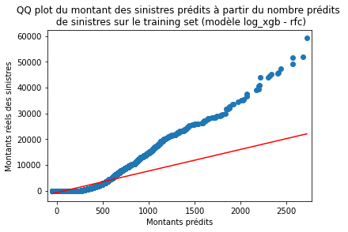

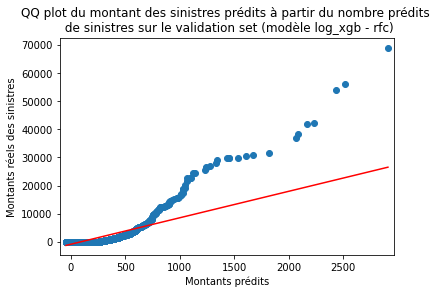

```python
pp_predictions_train = sm.ProbPlot(y_train_pred_weighted_4_copies_BM)
pp_claimValues_train = sm.ProbPlot(df_train_train.claimValue.values)
qqplot_2samples(pp_predictions_train, pp_claimValues_train, line='r', xlabel="Montants prédits", ylabel="Montants réels des sinistres")
plt.title("QQ plot du montant des sinistres prédits à partir du nombre prédits \n de sinistres sur le training set (modèle log_xgb - rfc)")

pp_predictions = sm.ProbPlot(y_val_pred_weighted_4_copies_BM)
pp_claimValues_val = sm.ProbPlot(df_val.claimValue.values)
qqplot_2samples(pp_predictions, pp_claimValues_val, line='r', xlabel="Montants prédits", ylabel="Montants réels des sinistres")
plt.title("QQ plot du montant des sinistres prédits à partir du nombre prédits \n de sinistres sur le validation set (modèle log_xgb - rfc)")
```

```python
print(f"Prédictions du montant des sinistres sur validation set (modèle xgb avec nombre prédits de sinistre et transformation log):\
\n- R²: {r2_score(df_val.claimValue.values, y_val_pred_weighted_4_copies_BM)}\
\n- MAE (perte l1): {mean_absolute_error(df_val.claimValue.values, y_val_pred_weighted_4_copies_BM)}\
\n-  Median Absolute Error: {median_absolute_error(df_val.claimValue.values, y_val_pred_weighted_4_copies_BM)}")
```

```
Prédictions du montant des sinistres sur validation set (modèle xgb avec nombre prédits de sinistre et transformation log):
- R²: -0.00020283046568159158
- MAE (perte l1): 400.1996386542131
-  Median Absolute Error: 88.60044226301275
```

Le R² est nul ce qui n'est clairement pas une bonne nouvelle, cependant, en comparant le QQ Plot obtenu avec notre modèle RFC - XGB et celui obtenu précèdemment avec le modèle RFC - moyenne intra-groupe, on obtient de bien meilleurs résultats.

Les seuls problème sont le montant des primes ne suffisant pas à couvrir le montant des sinistres et l'existence de primes négatives.

## Ajout d'une prime collective $\mathcal{P_{coll}}$

Nous proposons dans cette partie d'ajouter une prime collective $\mathcal{P_{coll}}$ à la prime prédite $\hat{P}$

### Première méthode : pondération entre prime pure et prime individuelle

Calculer un coefficient $\alpha$ tels que $$ \alpha \sum_{i=1}^{N} \hat{P_i} + N(1 - \alpha)\mathcal{P_{pure}} - \sum_{i=1}^N{Y_i} = obj $$ avec $\hat{P_i}$ la prime individuelle calculée grâce à notre modèle RFC - XGB sur le training set (à laquelle on remplace les valeurs négatives par des 0) et $obj$ un objectif de résultat comptable (fixé par le top management par exemple).

$ \alpha \sum_{i=1}^{N} \hat{P_i} + N(1 - \alpha)\mathcal{P_{pure}} $ représente un compromis entre la prime individuelle et la prime collective et $obj$ est fixé afin de résoudre l'équation pour $\alpha$ et représente par exemple un objectif de rentabilité sur un portefeuille. On prendra par la suite $obj = 25 000$.

On obtient ainsi $$ \alpha = \frac{obj + \sum_{i=1}^N{Y_i} - N\mathcal{P_{pure}}}{\sum_{i=1}^N{\hat{P_i}} - N\mathcal{P_{pure}}} $$ où $\mathcal{P_{pure}} = \mathbb{E(\mathbf{Y})}$

Cette méthode est cependant assez limité est dépend beaucoup de la qualité des prédictions. Par exemple, le dénominateur n'est rien d'autre que l'écart entre le montant total des primes et le montant total des sinistres, or si cet écart est trop important, $\alpha$ sera très petit et la part de la prime individuelle sera négligeable. Avec nos résultats, nous un $\alpha$ négatif et très proche de 0. Cette méthode ne peut donc pas être utilisée.

```python
obj = 25000
N = len(df_train_train)  # 50 000
Sigma_Y = df_train_train.claimValue.sum()
alpha = (obj + Sigma_Y - train_stats_means.pp * N) / (y_train_pred_weighted_4_copies_no0.sum() - train_stats_means.pp * N)
alpha
```

```
-0.002765072235521692
```

### Seconde Méthode : distribution équitable

Nous proposons ici de répartir l'écart entre la somme des primes prédites par notre modèle sur le training set et le montant total des sinistres sur le training set de manière égale entre chaque assurés. On cherche ainsi $\mathcal{P_{eq}}$ telle que: $$ \sum_{i=1}^N{\bigl(\hat{P_i} + \mathcal{P_{eq}}\bigl)} - \sum_{i=1}^N{Y_i} = obj $$ On trouve $$ \mathcal{P_{eq}} = \frac{1}{N}\biggl(obj + \sum_{i=1}^N{Y_i} - \sum_{i=1}^N{\hat{P_i}}\biggl) $$

```python
P_eq = (obj + Sigma_Y - y_train_pred_weighted_4_copies_no0.sum())/N
P_eq
```

```
181.32710230015527
```

En ajoutant cette prime collective à tout les assurés on obtient les valeurs suivantes :

```python
y_train_p_eq = y_train_pred_weighted_4_copies_no0 + P_eq
y_val_p_eq = y_val_pred_weighted_4_copies_no0 + P_eq
print(f"Bilan training set: {y_train_p_eq.sum() - Sigma_Y}")
print(f"Bilan validation set: {y_val_p_eq.sum() - df_val.claimValue.sum()}")
```

```
Bilan training set: 25000.000000001863
Bilan validation set: -123198.61488148477
```

Le bilan négatif peut s'expliquer par un déséquilibre entre le training set et le validation set. Le fait que le validation set soit plus petit augmente également la variance du montant du passif de l'assuré.

Avantages :

- On fait payer à tous les individus un montant minimum
- On instaure une solidarité dans le portefeuille.
- La méthode n'ajoute pas de risque de modèle supplémentaire à l'estimation faite par la simulation.
- Simplicité d'implémentation
- Cette méthode permet de tarifer très bas sans perdre les très bon risque car ils ne paieront que la prime minimale. Inconvénients
- On discrime peu les mauvais les risques ce qui peut les pousser à vouloir rejoindre le portefeuille.

### Troisième Méthode

La troisième méthode à pour but de construire une prime minimale à partir des mauvaises prédictions. Dans la base validation, on considère que l'individu appartient à la catégorie dans laquelle il a la plus grande probabilité. Ensuite on compare cette estimation avec la catégorie dans laquelle il appartient réellement. Grâce à cela, on trouve les individus qui sont dans la mauvaise catégorie. Pour trouver la prime minimale, on fait alors la somme de leurs sinistres divisée par le nombre total de personne simulé. Cette nouvelle prime est alors redistribuée équitablement entre tous les assurés.

Avantages :

- permet de se couvrir d'une partie du risque de modèle : en effet, plus le modèle réalise de mauvaise prédictions, plus la prime minimale augmente.
- Cette méthode permet de tarifer très bas pour les très bon risque car ils ne paieront que la prime minimale.

Inconvénient :

- Difficile de calibrer un modèle pour obtenir un nombre de sinistre précis du fait du déséquilibre dans un portefeuille auto des classes sinistrées (environ 80 % d'un portefeuille auto n'engendre pas de sinistre)

Il est possible de faire les deux méthodes et de prendre la valeurs maximale , afin d être en positif dans le bilan et se protèger contre les mauvaises performances d'un modèle.

### Quatrième Méthode

La quatrième méthode est une variante de la seconde qui a pour but de redistribuer la moins value, augmenté de l'objectif. Sauf que cette fois la valeur est sous la forme d'un coefficient qui s'applique à toutes les variables intragroupes.

$$ obj = a*\mathbb{P}(X = 1)*\mathbb{E}( Y | X = 1) + b*\mathbb{P}(X = 2)*\mathbb{E}(Y | X = 2)+ c*\mathbb{P}(X > 3)*\mathbb{E}(Y | X > 3) $$

Avec a, b et c des constantes que l'on peut faire bouger afin de faire varier plus ou moins l'impact d'appartenir à un groupe, et X le nombre de sinistres. A l'aide de cette méthode on peut par exemple décider de faire payer encore plus les personnes que l'on perçoit comme étant à risque et leurs faire supporter la moins value, par exemple en fixant a = b = 1. On peut aussi imaginer que les a, b et c sont fixés par un expert.

Avantages :

- La méthode peut être modifié
- On peut intégrer un avis d'expert

Incovénient :

- Il faut créer trois variables supplémentaires

Finalement, pour notre tarification nous avons utilisé la seconde méthode.

# Conclusion

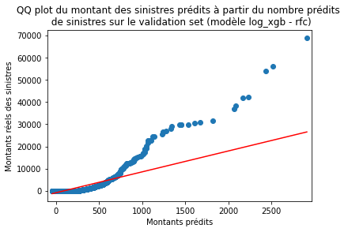